# R Notebook

```r
library(tidyverse)
library(janitor)
library(fastDummies)
library(GGally)
library(ggfortify)
library(mosaic)
library(mosaicData)
library(corrplot)
```

read in data #########

```r
housing_prices <- read_csv("data/housing_prices.csv")
housing_prices
```

Notes:

what does one row represent? An aggregate of a district in California

some variables are row sums, some are “stats”, like averages –> do some feature engineering / variable transformation to get more “stats” that are meaningful to me about these houses

Lets do some feature engineering - the data set we start with is the “raw material” - We can use those to make more meaning, aid interpretation

```r
house <- housing_prices %>%
  mutate(bedrooms_per_house = total_bedrooms / households,
         rooms_per_house = total_rooms / households,
         people_per_house = population / households,
         bedrooms_per_person = total_bedrooms / population,
         rooms_per_person = total_rooms / population,
         bedrooms_per_room = total_bedrooms / total_rooms,
         non_bedrooms_per_house = room_per_house - bedrooms_per_house)
```

[output not shown]

```r
skimr::skim(house)

glimpse(house)
```

extra idea: start using long & lats to make more meaning –> joining to external city coordinate data, creating labels, flags, or things

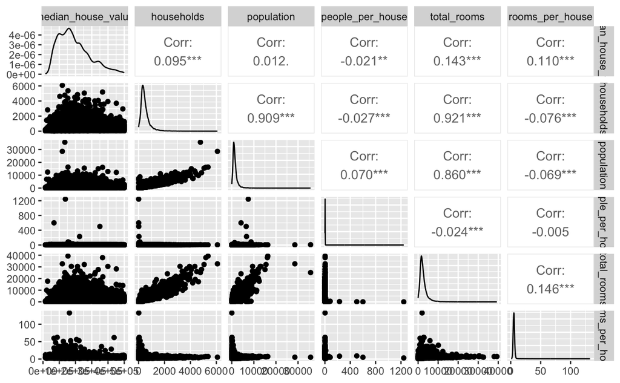

household assumption - “Proxy” for being in an urban/city area

```r
house %>%
  select_if(is.numeric) %>%
  skimr::skim()
```

```r
library(raster)
library(leaflet)

raster <- rasterFromXYZ(housing_prices %>%
  dplyr::select(longitude, latitude, median_house_value), crs = "+proj=longlat +ellps=WGS84 +datum=WGS84 +no_defs")

pal <- colorNumeric(c("blue", "red", "yellow"), values(raster),
  na.color = "transparent")

leaflet() %>%
  addTiles() %>%
  addRasterImage(raster, colors = pal, opacity = 0.7) %>%
  addLegend(pal = pal, values = values(raster),
    title = "Median House Value")
```

[interactive chart not shown]

Log Transformations - truncates data - helps with skewed data

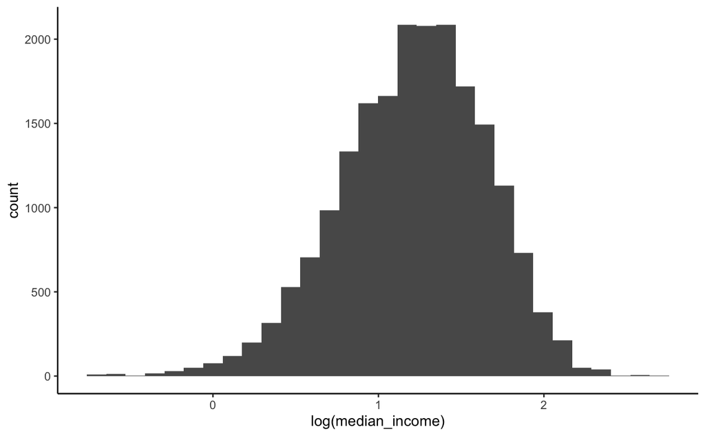

task 1 #########

```r
ggpairs(housing_prices, columns = c("total_rooms", "total_bedrooms"))
```

[output not shown]

they are strongly correlated with a correlation coefficient of 0.934

linear distribution

very skewed to the right

task 2 ########

| housing_median_age | total_rooms | population | households | median_income | median_house_value | ocean_proximity |
| --- | --- | --- | --- | --- | --- | --- |
| 41 | 880 | 322 | 126 | 8.3252 | 452600 | NEAR BAY |
| 21 | 7099 | 2401 | 1138 | 8.3014 | 358500 | NEAR BAY |
| 52 | 1467 | 496 | 177 | 7.2574 | 352100 | NEAR BAY |
| 52 | 1274 | 558 | 219 | 5.6431 | 341300 | NEAR BAY |
| 52 | 1627 | 565 | 259 | 3.8462 | 342200 | NEAR BAY |
| 52 | 919 | 413 | 193 | 4.0368 | 269700 | NEAR BAY |
| 52 | 2535 | 1094 | 514 | 3.6591 | 299200 | NEAR BAY |
| 52 | 3104 | 1157 | 647 | 3.1200 | 241400 | NEAR BAY |
| 42 | 2555 | 1206 | 595 | 2.0804 | 226700 | NEAR BAY |
| 52 | 3549 | 1551 | 714 | 3.6912 | 261100 | NEAR BAY |

[output cut: 990 more lines]

task 3 #########

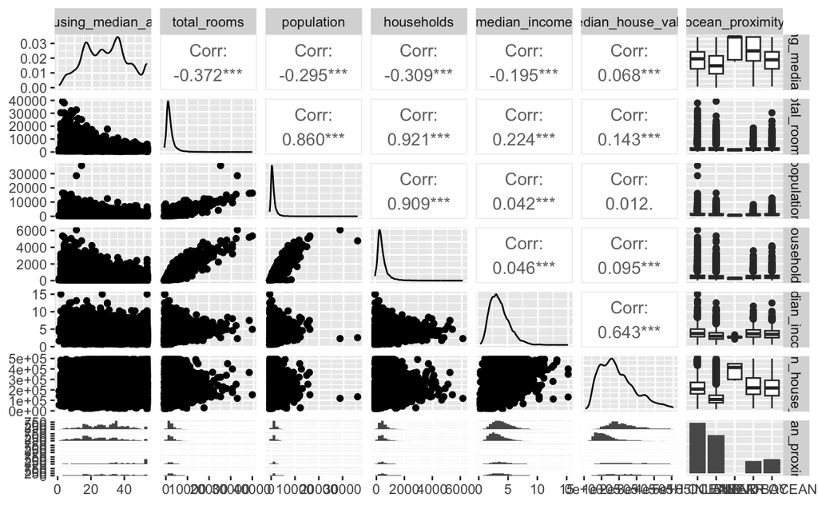

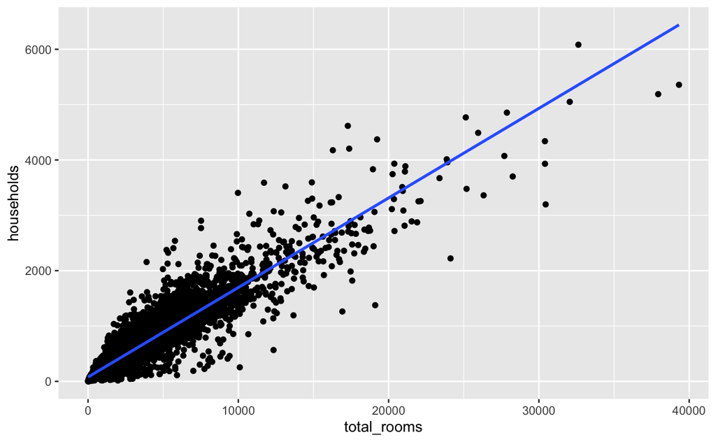

```r
par(mfrow = c(2,2))

# plot housebolds ~ total rooms

housing_prices %>%
  ggplot(aes(total_rooms, households)) +
  geom_point() +
  geom_smooth(method = "lm", se = FALSE)
```

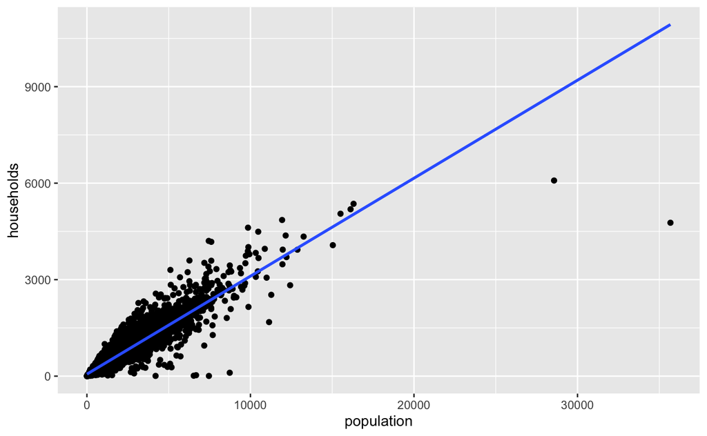

```r
# households ~ population

housing_prices %>%
  ggplot(aes(population, households)) +
  geom_point() +
  geom_smooth(method = "lm", se = FALSE)
```

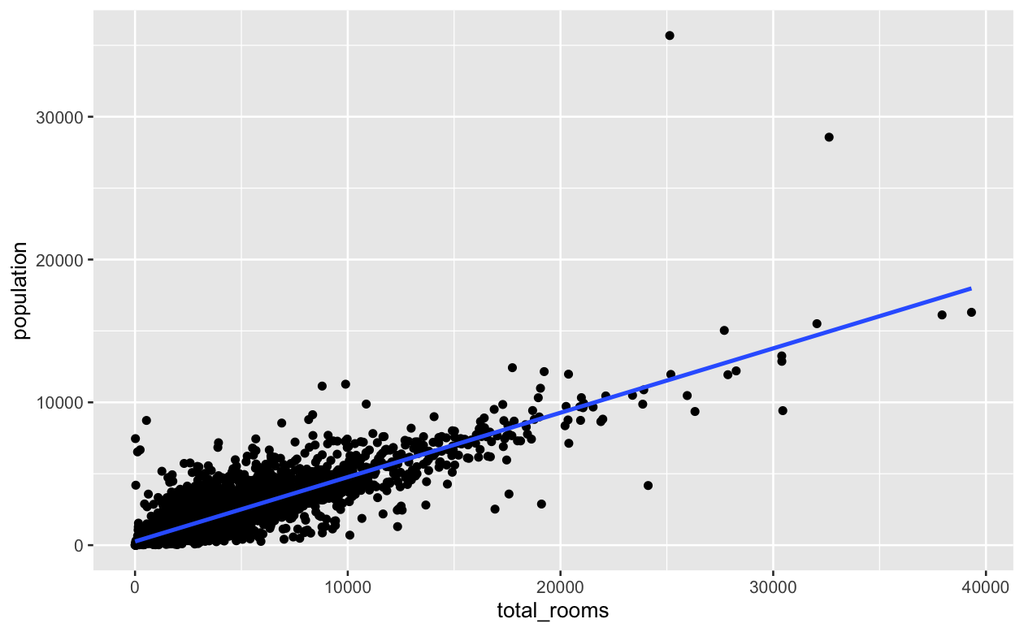

```r
# population ~ total_rooms

housing_prices %>%
  ggplot(aes(total_rooms, population)) +
  geom_point() +
  geom_smooth(method = "lm", se = FALSE)
```

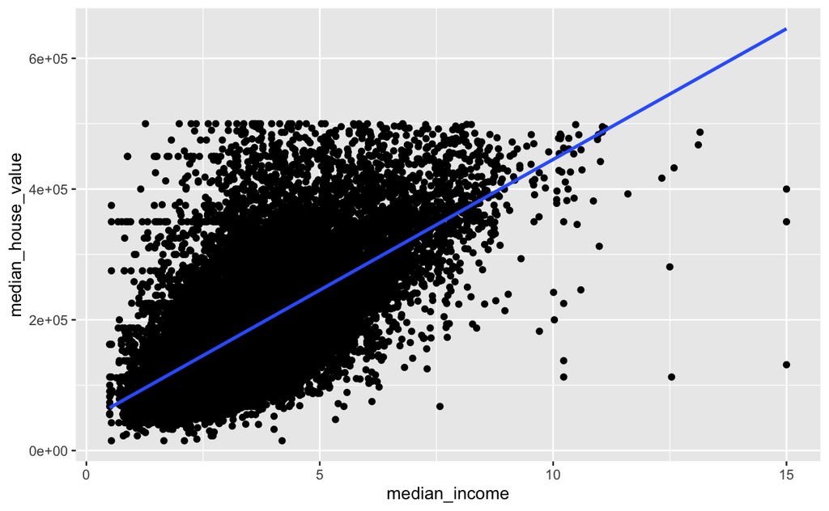

```r
# median_house_value ~ median_income

housing_prices %>%
  ggplot(aes(median_income, median_house_value)) +
  geom_point() +
  geom_smooth(method = "lm", se = FALSE)
```

task 4 ########

| housing_median_age | total_rooms | population | households | median_income | median_house_value | ocean_proximity_INLAND | ocean_proximity_ISLAND | ocean_proximity_NEAR BAY | ocean_proximity_NEAR OCEAN |
| --- | --- | --- | --- | --- | --- | --- | --- | --- | --- |
| 41 | 880 | 322 | 126 | 8.3252 | 452600 | 0 | 0 | 1 | 0 |
| 21 | 7099 | 2401 | 1138 | 8.3014 | 358500 | 0 | 0 | 1 | 0 |
| 52 | 1467 | 496 | 177 | 7.2574 | 352100 | 0 | 0 | 1 | 0 |
| 52 | 1274 | 558 | 219 | 5.6431 | 341300 | 0 | 0 | 1 | 0 |
| 52 | 1627 | 565 | 259 | 3.8462 | 342200 | 0 | 0 | 1 | 0 |
| 52 | 919 | 413 | 193 | 4.0368 | 269700 | 0 | 0 | 1 | 0 |
| 52 | 2535 | 1094 | 514 | 3.6591 | 299200 | 0 | 0 | 1 | 0 |
| 52 | 3104 | 1157 | 647 | 3.1200 | 241400 | 0 | 0 | 1 | 0 |
| 42 | 2555 | 1206 | 595 | 2.0804 | 226700 | 0 | 0 | 1 | 0 |
| 52 | 3549 | 1551 | 714 | 3.6912 | 261100 | 0 | 0 | 1 | 0 |

[output cut: 990 more lines]

task 5 ##########

```r
# regress median_house_value ~ median_income

lm1 <- lm(median_house_value ~ median_income, data = housing_prices)

summary(lm1)
```

```
Call:
lm(formula = median_house_value ~ median_income, data = housing_prices)

Residuals:
    Min      1Q  Median      3Q     Max
-513966  -51564  -13979   36549  403935

Coefficients:
              Estimate Std. Error t value Pr(>|t|)
(Intercept)    45457.0     1359.0   33.45   <2e-16 ***
median_income  39987.0      339.9  117.64   <2e-16 ***
---
Signif. codes:  0 ‘***’ 0.001 ‘**’ 0.01 ‘*’ 0.05 ‘.’ 0.1 ‘ ’ 1

Residual standard error: 74870 on 19673 degrees of freedom
Multiple R-squared:  0.4129,    Adjusted R-squared:  0.4129
F-statistic: 1.384e+04 on 1 and 19673 DF,  p-value: < 2.2e-16
```

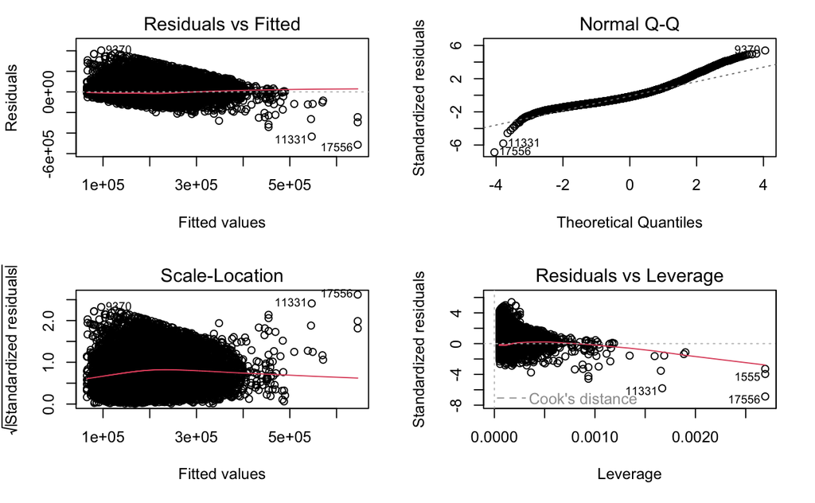

```r
par(mfrow = c(2,2))
plot(lm1)
```

task 6 ########

```r
lm2 <- lm(median_house_value ~ median_income + housing_median_age, data = housing_prices)

summary(lm2)
```

```
Call:
lm(formula = median_house_value ~ median_income + housing_median_age,
    data = housing_prices)

Residuals:
    Min      1Q  Median      3Q     Max
-578542  -49267  -12466   35993  424519

Coefficients:
                   Estimate Std. Error t value Pr(>|t|)
(Intercept)        -7997.53    1944.06  -4.114 3.91e-05 ***
median_income      42420.02     334.93 126.655  < 2e-16 ***
housing_median_age  1567.98      42.04  37.294  < 2e-16 ***
---
Signif. codes:  0 ‘***’ 0.001 ‘**’ 0.01 ‘*’ 0.05 ‘.’ 0.1 ‘ ’ 1

Residual standard error: 72360 on 19672 degrees of freedom
Multiple R-squared:  0.4517,    Adjusted R-squared:  0.4517
F-statistic:  8104 on 2 and 19672 DF,  p-value: < 2.2e-16
```

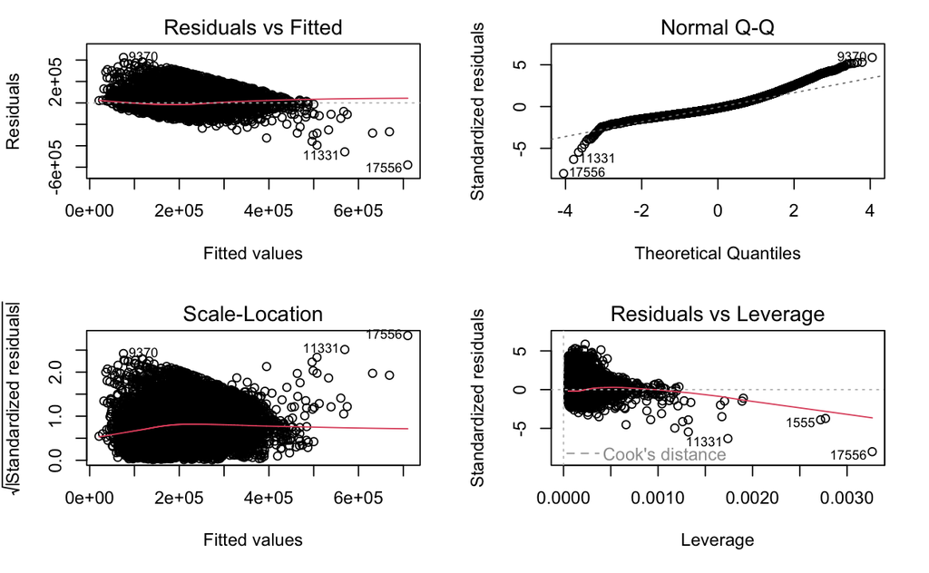

```r
par(mfrow = c(2,2))
plot(lm2)
```

diagnostics fairly similar to before, better fit for assumption of homoskedasticity

```r
lm2
```

```
Call:
lm(formula = median_house_value ~ median_income + housing_median_age,
    data = housing_prices)

Coefficients:
       (Intercept)       median_income  housing_median_age
             -7998               42420                1568
```

results suggest a 1 unit increase in median_income is associated with a 42420 increase in median_house_value, holding all other factors constant.

a 1 unit increase in housing_median_age is associated with a 1568 increase in median_house_age, holding all other factors constant.

Extension ##########

task 1 ##########

```r
lm3
```

```
Call:
lm(formula = median_house_value ~ log(median_income) + housing_median_age +
    population + log(median_income):housing_median_age, data = housing_prices)

Coefficients:
                          (Intercept)                     log(median_income)                     housing_median_age
                           -12674.297                             130280.757                                989.159
                           population  log(median_income):housing_median_age
                                2.988                                455.932
```

I would say the predicator is justified given that it would be expected that given a person’s age, they are more likely to have a higher income – having a greater impact on the median housing price.

should probably change median_house_value to natural logarithm to counter a non-linear distribution for a more accurate model.

task 2 #########

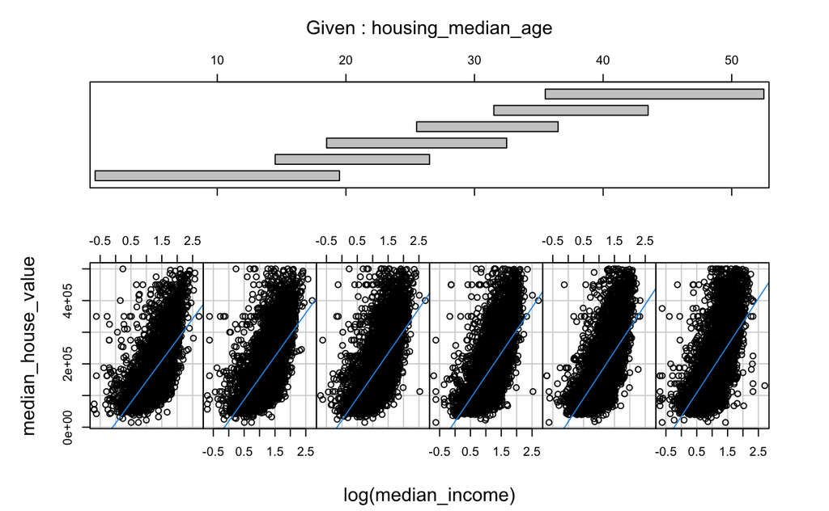

As age increases we see a greater correlation between median_house_value ~ log(median_income) gradient change is not that noticable

# log - log transformation model

```r
summary(lm4)
```

```
Call:
lm(formula = log(median_house_value) ~ log(median_income) + log(housing_median_age) +
    ocean_proximity, data = housing_prices)

Residuals:
     Min       1Q   Median       3Q      Max
-2.25388 -0.22181 -0.01789  0.20019  2.04117

Coefficients:
                           Estimate Std. Error t value Pr(>|t|)
(Intercept)               11.301188   0.018572 608.496  < 2e-16 ***
log(median_income)         0.665761   0.005775 115.275  < 2e-16 ***
log(housing_median_age)    0.024147   0.004528   5.333 9.78e-08 ***
ocean_proximityINLAND     -0.481320   0.005830 -82.557  < 2e-16 ***
ocean_proximityISLAND      0.774226   0.150337   5.150 2.63e-07 ***
ocean_proximityNEAR BAY    0.041816   0.008266   5.058 4.26e-07 ***
ocean_proximityNEAR OCEAN  0.038894   0.007715   5.041 4.67e-07 ***
---
Signif. codes:  0 ‘***’ 0.001 ‘**’ 0.01 ‘*’ 0.05 ‘.’ 0.1 ‘ ’ 1

Residual standard error: 0.336 on 19668 degrees of freedom
Multiple R-squared:  0.6031,    Adjusted R-squared:  0.603
F-statistic:  4981 on 6 and 19668 DF,  p-value: < 2.2e-16
```

visualise skew:

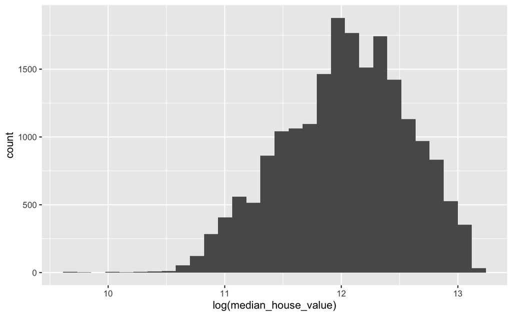

```r
library(leaflet)
```

[interactive chart not shown]